# MDA2025-U2-Losungen

```python
import numpy as np
import matplotlib.pyplot as plt
import matplotlib.cm as cm

import warnings
warnings.filterwarnings(action='ignore')
```

### Gradient

Berechnen Sie den Gradienten von $$z(x,y) = 3x \ln\left(\sqrt{x^2 +y^2}\right) - \cos(xy^2 - \pi x)$$ am Punkt $\left( \begin{array}{c} 1 \\ 0 \end{array} \right)$.

#### Lösungen

partielle Ableitungen:

$z_x = 3\ln(\sqrt{x^2 +y^2}) + \frac{3x^2}{x^2 + y^2} + (y^2 - \pi)\sin(xy^2 - \pi x)$

$z_y = \frac{3xy}{x^2+y^2} + 2xy\sin(xy^2 - \pi x)$

Gradient:

$\nabla z = \left[ \begin{array}{c} z_x \\ z_y \end{array}\right] = \left[ \begin{array}{c} 3\ln(\sqrt{x^2 +y^2}) + \frac{3x^2}{x^2 + y^2} + (y^2 - \pi)\sin(xy^2 - \pi x) \\ \frac{3xy}{x^2+y^2} + 2xy\sin(xy^2 - \pi x) \end{array} \right]$

Gradient am Punkt $P = (1,0)$:

$\nabla z = \left[ \begin{array}{c} 3 \\ 0 \end{array} \right]$

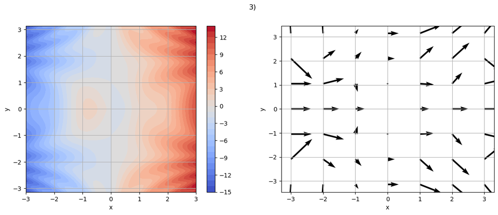

```
Gradient an [1,0]: x = 3.0000, y= 0.0000
```

```python
fig = plt.figure(figsize=(14,5))

x = np.linspace(-3,3,101)
y = np.linspace(-np.pi,np.pi,101)
X,Y = np.meshgrid(x,y)
Z = 3*X*np.log(np.sqrt(X**2+Y**2)) - np.cos(X*Y**2 - np.pi*X)
ax1 = fig.add_subplot(121)
clb = ax1.contourf(X,Y,Z, 31, cmap=cm.coolwarm)
ax1.set_xlabel('x')
ax1.set_ylabel('y')
ax1.grid()
fig.colorbar(clb, ax=ax1)

x = np.linspace(-3,3,7)
y = np.linspace(-np.pi,np.pi,7)
X,Y = np.meshgrid(x,y)
ax2 = fig.add_subplot(122)
U = 3*np.log(np.sqrt(X**2+Y**2)) + 3*X*X/(X**2+Y**2) + np.sin(X*Y**2 - np.pi*X)*(Y**2 - np.pi)
V = 3*X*Y/(X**2+Y**2) + np.sin(X*Y**2 - np.pi*X)*(2*X*Y)
ax2.quiver(X,Y,U,V,scale_units='xy', angles='xy', scale=10)
ax2.set_xlabel('x')
ax2.set_ylabel('y')
ax2.grid()
fig.suptitle('3)')
plt.show()
gx = 3*np.log(np.sqrt(1**2+0**2)) + 3*1*1/(1**2+0**2) + np.sin(1*0**2 - np.pi*1)*(0**2 - np.pi)
gy = 3*1*0/(1**2+0**2) + np.sin(1*0**2 - np.pi*1)*(2*1*0)
print('Gradient an [1,0]: x = {0:.4f}, y= {1:.4f}'.format(gx,gy))
```

### Partielle Ableitungen höherer Ordnung

Gegeben ist die Funktion $z(x,y) = 3xy-cos(x-y)+x^3y^5$.

*a)* Zeigen Sie: $z_{xy} = z_{yx}$  
*b)* Zeigen Sie: $z_{xxy} = z_{xyx} = z_{yxx}$

Hinweis zur Notation: $f_{xy} = \frac{\partial}{\partial y}\left(\frac{\partial f}{\partial x} \right) = \frac{\partial^2f}{\partial x\partial y}$, $f_{xx} = \frac{\partial}{\partial x}\left(\frac{\partial f}{\partial x} \right) = \frac{\partial^2f}{\partial x^2}$

#### Lösung

*a)*  
$z_x = 3y + sin(x-y) + 3x^2y^5$  
$z_y = 3x - sin(x-y) + x^35y^4$  
$z_{xy} = \frac{\partial}{\partial y} (z_x) = \color{red}{3 - cos(x-y) + 3x^25y^4}$  
$z_{yx} = \frac{\partial}{\partial x} (z_y) = \color{red}{3 - cos(x-y) + 3x^25y^4}$  
*b)*  
$z_{xx} = \frac{\partial}{\partial x} (z_x) = cos(x-y) + 6xy^5$  
$z_{xxy} = \frac{\partial}{\partial y} (z_{xx}) = \color{blue}{sin(x-y) + 6x5y^4}$  
$z_{xyx} = \frac{\partial}{\partial x} (z_{xy}) = \color{blue}{sin(x-y) + 6x5y^4}$  
$z_{yxx} = \frac{\partial}{\partial x} (z_{yx}) = \color{blue}{sin(x-y) + 6x5y^4}$

### Partielle Ableitungen höherer Ordnung

Zeigen Sie, dass $$u(x,y,z) = \dfrac{a}{\sqrt{x^2 + y^2 +z^2}} + b$$ eine Lösung der folgenden partiellen Differentialgleichung (Laplace-Gleichung) $$u_{xx} + u_{yy} + u_{zz} = 0$$ ist.

#### Lösung

Struktur der partiellen Ableitung 1. Ordnung:

$u_x = -\dfrac{ax}{(x^2 + y^2 +z^2)^{\frac{3}{2}}}$

- analoge Struktur für die anderen partiellen Ableitungen 1. Ordnung

partielle Ableitungen 2. Ordnung:

$u_{xx} = \dfrac{a(2x^2 - y^2 - z^2)}{(x^2 + y^2 +z^2)^{\frac{5}{2}}}$

$u_{yy} = \dfrac{a(2y^2 - x^2 - z^2)}{(x^2 + y^2 +z^2)^{\frac{5}{2}}}$

$u_{zz} = \dfrac{a(2z^2 - x^2 - y^2)}{(x^2 + y^2 +z^2)^{\frac{5}{2}}}$

Einsetzen in Laplace-Gleichung:

$ \dfrac{a(2x^2 - y^2 - z^2) + a(2y^2 - x^2 - z^2) + a(2z^2 - x^2 - y^2)}{(x^2 + y^2 +z^2)^{\frac{5}{2}}} = \dfrac{a\left(2x^2 - x^2 - x^2 + 2y^2 - y^2 - y^2 + 2z^2 - z^2 - z^2\right)}{(x^2 + y^2 +z^2)^{\frac{5}{2}}} = 0$

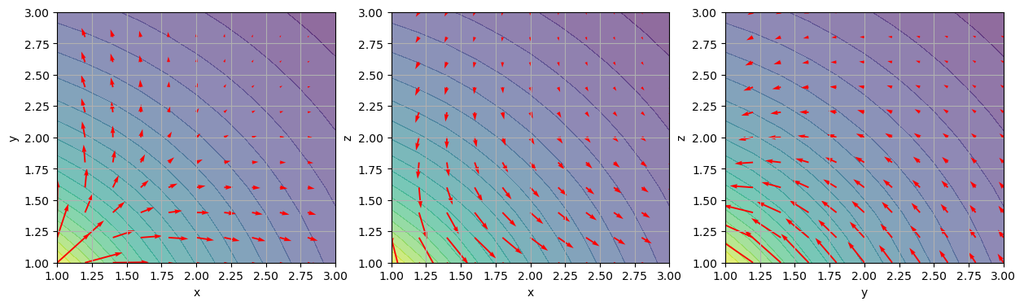

```python
# wertebereich der parameter
x = np.linspace(1,3,11)
y = np.linspace(1,3,11)
z = np.linspace(1,3,11)

# parameter der funktion
a = 1
b = 1

fig, axs = plt.subplots(1,3,figsize=(15,4))

# in der x-y-Ebene
cax = axs[0]
xx, yy = np.meshgrid(x,y)
zz = 0
u = a*(2*xx**2 - yy**2 - zz**2)/(xx**2 + yy**2 + zz**2)**(5/2)
v = a*(2*yy**2 - xx**2 - zz**2)/(xx**2 + yy**2 + zz**2)**(5/2)
w = a*(2*zz**2 - xx**2 - yy**2)/(xx**2 + yy**2 + zz**2)**(5/2)
cax.contourf(xx, yy, a/(xx**2 + yy**2 + zz**2)**(1/2) + b, 20, alpha=0.6)
cax.quiver(xx, yy, u, v, scale=0.75, scale_units='xy', angles='xy', color='red')
cax.set_xlabel('x')
cax.set_ylabel('y')
cax.grid()

# in der x-z-Ebene
cax = axs[1]
xx, zz = np.meshgrid(x,z)
yy = 0
u = a*(2*xx**2 - yy**2 - zz**2)/(xx**2 + yy**2 + zz**2)**(5/2)
v = a*(2*yy**2 - xx**2 - zz**2)/(xx**2 + yy**2 + zz**2)**(5/2)
w = a*(2*zz**2 - xx**2 - yy**2)/(xx**2 + yy**2 + zz**2)**(5/2)
cax.contourf(xx, zz, a/(xx**2 + yy**2 + zz**2)**(1/2) + b, 20, alpha=0.6)
cax.quiver(xx, zz, u, v, scale=0.75, scale_units='xy', angles='xy', color='red')
cax.set_xlabel('x')
cax.set_ylabel('z')
cax.grid()

# in der y-z-Ebene
cax = axs[2]
yy, zz = np.meshgrid(y,z)
xx = 0
u = a*(2*xx**2 - yy**2 - zz**2)/(xx**2 + yy**2 + zz**2)**(5/2)
v = a*(2*yy**2 - xx**2 - zz**2)/(xx**2 + yy**2 + zz**2)**(5/2)
w = a*(2*zz**2 - xx**2 - yy**2)/(xx**2 + yy**2 + zz**2)**(5/2)
cax.contourf(yy, zz, a/(xx**2 + yy**2 + zz**2)**(1/2) + b, 20, alpha=0.6)
cax.quiver(yy, zz, u, v, scale=0.75, scale_units='xy', angles='xy', color='red')
cax.set_xlabel('y')
cax.set_ylabel('z')
cax.grid()

plt.show()
```

### Totales Differential

Bestimmen Sie das totale Differential folgender Funktionen:

- $z(x,t) = \dfrac{t^2 + x}{2t - 4x}$
- $z(u,v,w) = \ln \sqrt{u^2 +v^2 +w^2}$
- $z(x,y) = 4 x^3 y - 3 \mathrm{e}^{y}x$

### Lösung

Totales Differential: $\mathrm{d} \varphi = \dfrac{\partial \varphi}{\partial x}\mathrm{d}x + \dfrac{\partial \varphi}{\partial y}\mathrm{d}y + \dfrac{\partial \varphi}{\partial z}\mathrm{d}z$

- $\mathrm{d}z = \dfrac{2t^2 - 8tx - 2x}{(2t - 4x)^2}\mathrm{d}t + \dfrac{4t^2 + 2t}{(2t - 4x)^2}\mathrm{d}x$
- $\mathrm{d}z = \dfrac{u}{u^2 + v^2 + w^2}\mathrm{d}u + \dfrac{v}{u^2 + v^2 + w^2}\mathrm{d}v + \dfrac{w}{u^2 + v^2 + w^2}\mathrm{d}w$
- $\mathrm{d}z = (12x^2y - 3\mathrm{e}^{y})\mathrm{d}x + (4x^3 - 3x\mathrm{e}^{y})\mathrm{d}y$

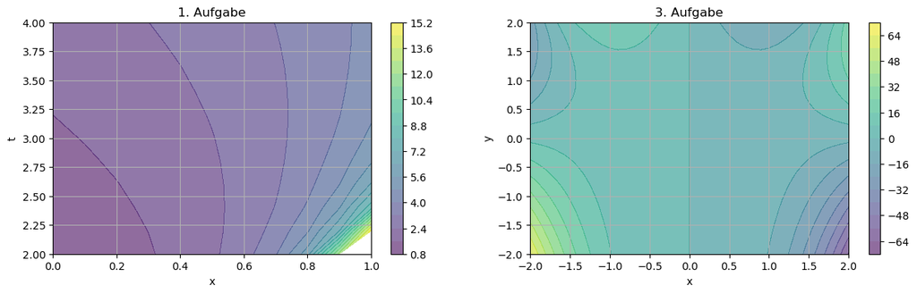

```python
fig, axs = plt.subplots(1,2, figsize=(15,4))
cax = axs[0]
x = np.linspace(0,1,11)
t = np.linspace(2,4,11)
xx, tt = np.meshgrid(x,t)
clb = cax.contourf(xx, tt, (tt**2+xx)/(2*tt-4*xx), 20, alpha=0.6)
cax.set_xlabel('x')
cax.set_ylabel('t')
cax.set_title('1. Aufgabe')
cax.grid()
fig.colorbar(clb, ax=cax)

cax = axs[1]
x = np.linspace(-2,2,41)
y = np.linspace(-2,2,41)
xx, yy = np.meshgrid(x,y)

clb = cax.contourf(xx, yy, 4*xx**3*yy - 3*np.exp(yy)*xx, 20, alpha=0.6)
cax.set_xlabel('x')
cax.set_ylabel('y')
cax.set_title('3. Aufgabe')
fig.colorbar(clb, ax=cax)
cax.grid()

plt.show()
```

### Kettenregel

Berechnen Sie unter Anwendung der Kettenregel $\dot{z} = \mathrm{d} z/\mathrm{d} t$ für $$z(x,y) = x^2 + 6x y + 2y^2,$$ mit $x(t) = \cos(t), \; y(t) = \sin(t)$.

Welchen Wert hat $\dot{z}$ für $t = \pi /2$? Wie sieht diese Funktion grafisch aus?

#### Lösung

Kettenregel: $\dfrac{\mathrm{d}z}{\mathrm{d}t} = \dfrac{\partial z}{\partial x} \dfrac{\mathrm{d}x}{\mathrm{d}t} + \dfrac{\partial z}{\partial y} \dfrac{\mathrm{d}y}{\mathrm{d}t}$

- $\dfrac{\partial z}{\partial x} = 2x + 6y$
- $\dfrac{\mathrm{d}x}{\mathrm{d}t} = -\sin(t)$
- $\dfrac{\partial z}{\partial y} = 6x + 4y$
- $\dfrac{\mathrm{d}x}{\mathrm{d}t} = \cos(t)$

$\dfrac{\mathrm{d}z}{\mathrm{d}t} = -(2x + 6y)\sin(t) + (6x + 4y) \cos(t) = -(2\cos(t) + 6\sin(t))\sin(t) + (6\cos(t) + 4\sin(t)) \cos(t) = 2\cos(t)\sin(t) + 6(\cos^2(t) - \sin^2(t))$

Anmerkung: $\cos^2(t) - \sin^2(t) = \cos(2t)$

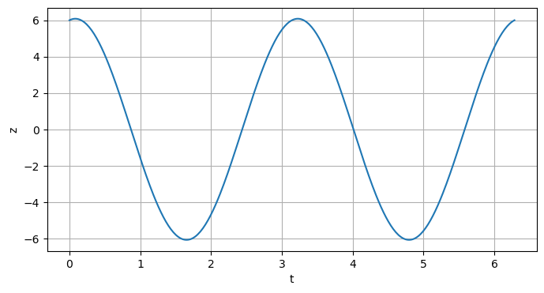

```
z at pi/2: -6.0000
```

```python
t = np.linspace(0, 2*np.pi, 361)
z = 2*np.cos(t)*np.sin(t) + 6*np.cos(2*t)

fig = plt.figure(figsize=(8,4))
ax = fig.add_subplot(111)
ax.plot(t,z)
ax.set_xlabel('t')
ax.set_ylabel('z')
ax.grid()
plt.show()

t = np.pi/2
print('z at pi/2: {0:.4f}'.format(2*np.cos(t)*np.sin(t) + 6*np.cos(2*t)))
```

### Anwendung – Tangentialebene

Bestimmen Sie die Gleichung der Tangentialebene in P=(0;1;0) für die Funktion $z(x,y) = 4x^3y-3xe^y$.  
Korrektur: Der Punkt hatte eine falsche Z-Koordinate. (0;1;1) liegt nicht auf der Oberfläche.

#### Lösung

$z_x=12x^2y - 3e^y$  
$z_y=4x^3 -3xe^y$  
$z_x(0,1) = -3e$  
$z_y(0,1) = 0$  
Tangentialebene:  
$z -z_0 = z_x(x_0,y_0)*(x-x_0) + z_y(x_0,y_0)*(y-y_0)$  
$z = -3e(x-0) + 0*(y-1) = -3ex$

### Anwendung – Implizite Differentiation

Berechnen Sie die Tangentensteigung der Funktion $y(x)$ an dem Punkt, an dem $y=3$ und $x<0$, wenn diese Funktion implizit definiert ist: $\frac{x^2}{36}+\frac{y^2}{16}=1$.

### Optional

Zeigen Sie, dass die gemischten Ableitungen zweiter Ordnung der Funktion $f(x,y)$ bei $(x, y) = (0, 0)$ unterschiedlich sind.  
$f(x,y)=\begin{cases}\frac{xy^3-x^3y}{x^2+y^2} & \text{for } (x,y)\ne(0,0)\\0 & \text{for } (x,y)=(0,0)\end{cases}$

**(1)** For $(x,y)\ne(0,0)$ (using quotient rule): $f_x(x,y) = \dfrac{ -x^4y - 4x^2y^3 + y^5 }{(x^2+y^2)^2}$  
**(2)** For $(x,y)=(0,0)$ (from definition): $f_x(0,0) = \lim\limits_{h\rightarrow0} \dfrac{f(0+h,0)-f(0,0)}{h} = \lim\limits_{h\rightarrow0} \dfrac{0}h = 0 $  
**(3)** For $(x,y)\ne(0,0)$ (using quotient rule): $f_y(x,y) = \dfrac{-x^5 + 4x^3y^2 + xy^4}{(x^2+y^2)^2}$  
**(4)** For $(x,y)=(0,0)$ (from definition): $f_y(0,0) = \lim\limits_{h\rightarrow0} \dfrac{f(0,0+h)-f(0,0)}{h} = \lim\limits_{h\rightarrow0} \dfrac{0}h = 0 $  
**(5)** $f_{xy}(0,0) = \lim\limits_{h\rightarrow0}\dfrac{f_x(0,0+h) - f_x(0,0)}{h} = \lim\limits_{h\rightarrow0}\dfrac{\frac{h^5}{h^4}-0}{h}=1$  
**(6)** $f_{yx}(0,0) = \lim\limits_{h\rightarrow0}\dfrac{f_y(0+h,0) - f_y(0,0)}{h} = \lim\limits_{h\rightarrow0}\dfrac{\frac{-h^5}{h^4}-0}{h} = -1$